# SISMA - Dinâmica Visual de Transformações

[figure not shown]

**Sisma** é um programa elaborado com a proposta de gerar uma imagem dinâmica de transformações ocorridas entre reagentes e produtos de reações isoladas ou em rede, pela simples inserção de compostos (*object*) interligados por setas (*path*). Nesse sentido, o programa foi desenhado para facilitar a inserção de reagentes e vias metabólicas, **simulando o que se desenharia com um lápis e uma folha de papel em branco**.

O programa foi escrito em *Java* e permite visualizar e avaliar dinamicamente a transformação de reagentes e produtos em uma reação isolada, um fluxo metabólico, ou mapas complexos. O nome **Sisma** refere-se ao acrônimo para **Sistema de Mapas Autocatalíticos**. O programa realiza uma simulação visual e quantitativa num mapa de reações, pela percepção de *variações na tonalidade dos objetos* envolvidos em cada tranformação, tanto a partir de uma equação *default*, como introduzida pelo usuário.

**Características do SISMA**

Para o estudo das relações entre reagentes e produtos o programa permite a inserção de compostos (*Object*), caminhos (*Path*), figuras e anotações no mapa, armazenamento e leitura de mapas, simulação das variações nos teores relativos de cada composto por gráfico de pontos e linhas simultaneamente às que ocorrem no próprio mapa, pausa, interrupção, retrocesso e avanço da visualização a qualquer momento da simulação, geração automática e exportação de planilha contendo os valores numéricos de cada objeto transformado em cada instante, e impressão instantânea do mapa no ponto de uma transformação desejada. Dessa forma, o programa torna dinâmica a visualização de *forças e de fluxos* que são apresentados de forma estática em diagramas e mapas em *Bioquímica* e áreas afins.  
O programa foi desenvolvido em parceria com o Prof. Dr. Luiz Eduardo da Silva, do Departamento de Ciência da Computação (DCC/UNIFAL-MG) e três discentes de Iniciação Científica.

**Exemplo de telas**

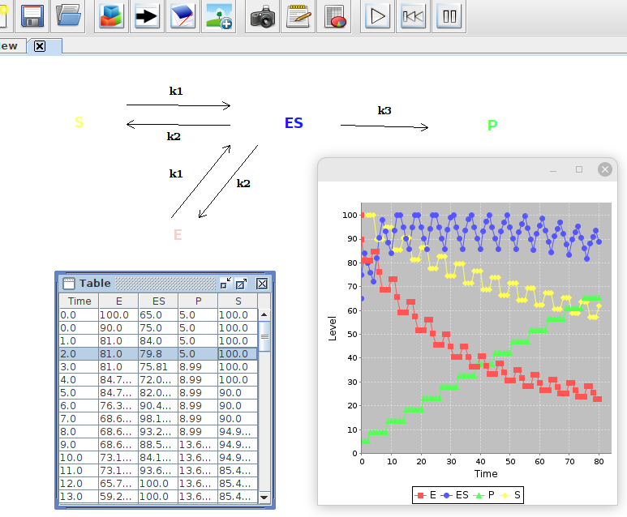

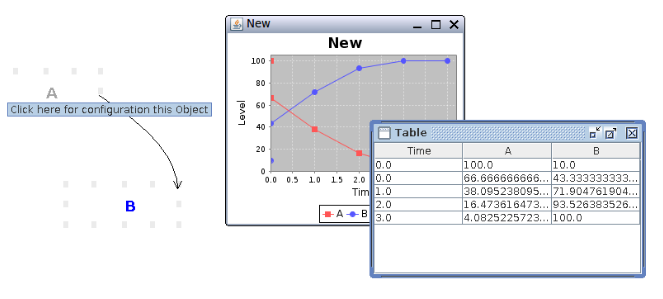

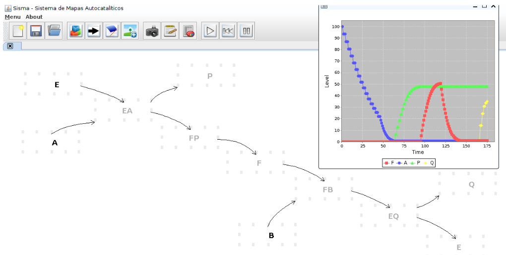

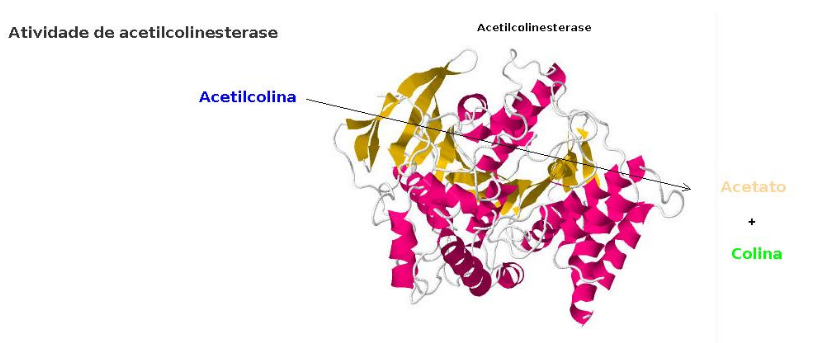

## Dica rápida de uso !

Para utilizar o **Sisma** baixe o arquivo do *link* acima e descompacte-o em seu PC. O programa não requer instalação, apenas máquina virtual [*JAVA*](https://www.java.com/pt-BR/download/manual.jsp). Para executá-lo, vá para a pasta *“dist”* e clique no arquivo executável de Java (*“Sisma_Realese_1.jar”*).

Este [**tutorial rápido**](https://www.youtube.com/watch?v=MPr5zWlJqbY) em *vídeo* ilustra o uso descrito abaixo.

Clique com o botão direito do mouse e selecione *Object* para inserção de um composto. Repita o último procedimento num outro local da *folha em branco* do programa, mas desta vez reduzindo a intensidade de cor na barra de rolagem. Agora ligue os dois objetos clicando num vértice de um deles e arrastando o mouse para o vértice de outro. Finalmente, clique em *OK* e rode a simulação pelo ícone *Play*, para visualizar a conversão de matizes do primeiro para o segundo objeto.

## Ebook

Para inserir *objetos* e *caminhos* no **Sisma**, bem como elaborar, simular e avaliar reações enzimáticas, cadeias ou redes metabólicas dinâmicas, baixe o ebook (ISBN: 978-65-00-52124-5).

## Exemplos de Mapas do Sisma

Condição de Briggs-Haldane do estado estacionário

Efeito de Vm e Km

Efeito do teor de enzima

Inibição por substrato

Equilíbrio T-R em enzima

Ajuste induzido

Efetor alostérico negativo

Efetor alostérico positivo

Glicólise

Metabolismo de carboidratos

Beta-oxidação de ácidos graxos

Mapa Metabólico